# Wpływ struktury rynku sprzedaży buraków cukrowych w Polsce na oceny opłacalności ich produkcji

Grzegorz Smoliński

17.02.2020

## Wstęp

Poniżej opisano przeprowadzone analizy statystyczne na zbiorze danych liczącym 141 obserwacji oraz 5 zmiennych. Celem była analiza, w jaki sposób obecna sytuacja na rynku sprzedaży buraków cukrowych wpływa na postrzeganie opłacalności uprawy buraków cukrowych przez rolników. W celu przeprowadzenia analiz, wzięto pod uwagę:

- areał uprawy buraków cukrowych
- z którym z przedsiębiorstw cukrowych respondent ma podpisaną umowę na dostarczenie buraków cukrowych
- czy respondent uważa, że ma wybór, z którym z przedsiębiorstw cukrowych może podpisać umowę
- czy buraki cukrowe stanowią uprawę, która przynosi największy dochód w gospodarstwie
- jak respondent ocenia opłacalność uprawy buraków cukrowych.

## Uwagi metodologiczne

Badanie odbyło się w dniach 3-11.02.2020 r. Przeprowadzono wywiady CATI ze 141 respondentami - rolnikami uprawiającymi min. 5 ha buraków cukrowych. Zastosowano dobór kwotowo-losowy, w którym kwoty ustalono na podstawie areału uprawy buraków cukrowych w poszczególnych województwach. Poniżej opisano uzyskane wyniki.

## Wyniki

### 1. Ocena opłacalności uprawy buraków cukrowych

Wszystkie przeprowadzone analizy miały na celu zbadanie wpływu wybranych zmiennych na ocenę opłacalności uprawy buraków cukrowych. Oceny te same w sobie okazały się dość niskie - rolnicy w większości postrzegają opłacalność wspomnianej uprawy na dziesięciostopniowej skali negatywnie.

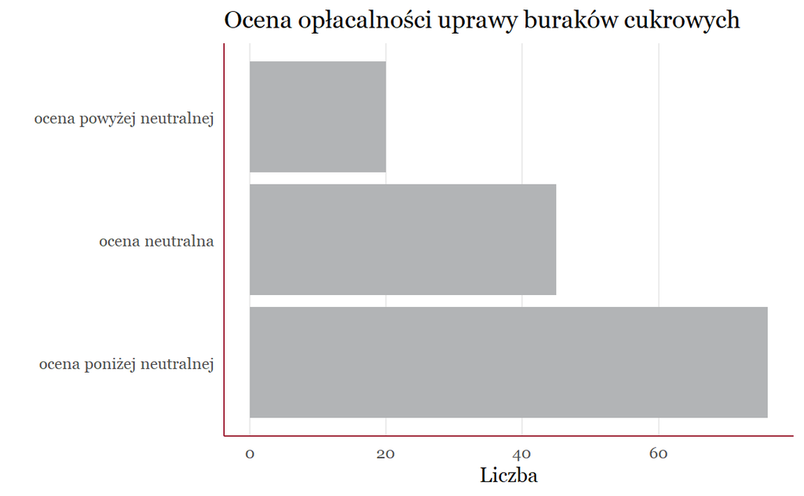

Na powyższym wykresie przyjęto, że odpowiedzi “5” i “6” będą traktowane jako odpowiedzi neutralne. Dominacja ocen negatywnych sama w sobie oczywiście jest interesująca, ale jest też trudna w interpretacji, ponieważ bez odniesienia do tego, co jest jej podłożem, niewiele można stwierdzić.

### 2. Możliwość wyboru przedsiębiorstwa cukrowego a ocena opłacalności uprawy buraków cukrowych

W Polsce funkcjonują cztery przedsiębiorstwa cukrowe, z którymi można podpisać umowę na sprzedaż buraków cukrowych: Krajowa Spółka Cukrowa (Polski Cukier), Nordzucker, Pfeifer & Langen, Südzucker. Geograficzne rozmieszczenie poszczególnych cukrowni oraz ich status właścicielski sprawiają jednak, że w praktyce nie zawsze można mówić o możliwości wyboru odbiorcy buraków cukrowych - na danym obszarze może bowiem funkcjonować tylko jedno przedsiębiorstwo (tj. odległość do innego producenta cukru może być postrzegana jako tak duża, że niemożliwa do pokonania, np. z racji ekonomicznej nieopłacalności). Badania pokazały, że zdecydowana większość rolników uważa, że nie ma wyboru, z kim podpisać umowę.

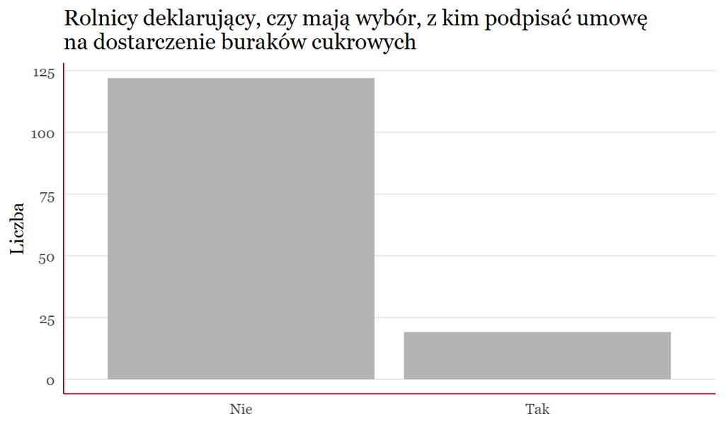

### 3. Udział buraków cukrowych w dochodzie gospodarstwa rolnego oraz posiadanie wyboru, z kim podpisać umowę a ocena opłacalności uprawy

Postrzeganie opłacalności uprawy może być zależne od tego, jak ważna - w sensie ekonomicznym - jest ta uprawa dla gospodarstwa rolnego. Jeśli wynik ekonomiczny gospodarstwa w dużym stopniu od niej zależy, niżej postrzegana opłacalność może stać się relatywnie jeszcze niższa - podobnie w przypadku, gdy jest ona wyższa od neutralnej. Co więcej, wpływ tej zmiennej może być powiązany z tym, czy respondent deklaruje, że ma wybór, z którym przedsiębiorstwem cukrowym podpisać umowę czy też nie - brak wyboru może być tym bardziej dotkliwy, im wyższy udział uprawy w dochodzie gospodarstwa.

Dane nie pozwalają jednak również w tym przypadku na żadne wnioski - liczba osób, które odpowiedziały, że uprawa buraka cukrowego stanowi większość dochodu w gospodarstwie jest niewielka, a jeszcze mniejsza jest liczba osób, które zadeklarowały, że nie mogą wybrać przedsiębiorstwa cukrowego, z którym podpiszą umowę, ale uprawa buraków cukrowych odpowiada w ich gospodarstwie za większość dochodu:

Posiadanie wyboru przedsiębiorstwa cukrowego a największy udział buraków cukrowych w dochodzie gospodarstwa

[output not shown]

* W nawiasach podano średnią ocenę opłacalności uprawy buraków cukrowych.

Wyniki nie są istotne statystycznie [^2], ani w przypadku testu, czy średnie oceny opłacalności dla osób, u których buraki cukrowe stanowią największy dochód w gospodarstwie, są inne niż średnie oceny opłacalności dla osób, u których buraki cukrowe nie stanowią największego dochodu w gospodarstwie, ani w przypadku osób, u których buraki cukrowe stanowią największy udział w dochodzie i jednocześnie osoby te nie mają wyboru przedsiębiorstwa cukrowego.

### 4. Posiadanie umowy z konkretnym przedsiębiorstwem cukrowym a ocena opłacalności uprawy

Jeśli postrzeganie przez respondentów tego, jak ich uprawa buraków cukrowych jest opłacalna, ma zależeć od relacji między sprzedawcą (rolnikiem) a kupującym (przedsiębiorstwem cukrowym), to trzeba również wziąć pod uwagę, że różnice mogą zależeć po prostu od tego, z kim rolnik współpracuje. Jes to tym bardziej uzasadnione, że rolnicy zazwyczaj, jak pokazały już przedstawione wyniki, nie mają wyboru, z kim podpisać umowę na sprzedaż buraków cukrowych. Na wykresie poniżej zaprezentowano średnie oceny opłacalności uprawy buraków cukrowych w zależności od przedsiębiorstwa cukrowego, któremu sprzedaje się plony.

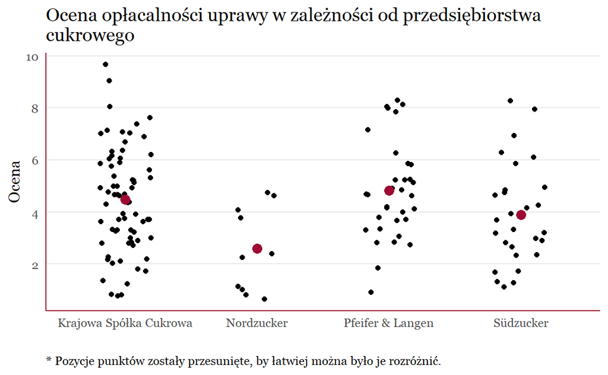

Średnie oceny zostały zaznaczone czerwoną kropką, natomiast czarne kropki odpowiadają liczbie rolników, którzy mają podpisane umowy z danym przedsiębiorstwem. W celu zbadania różnic w średnich ocenach posłużono się testem ANOVA. Analizy, oparte na symulacji, pokazały, że co najmniej jedna średnia różni się istotnie od co najmniej jednej średniej ($p = 0,02$). Dalsze testy wskazały Nordzucker jako to przedsiębiorstwo, które ma niższą średnią ocenę opłacalności uprawy w porównaniu do Krajowej Spółki Cukrowej oraz Pfeifer & Langen, a ponieważ jest tak pomimo niewielkiej liczby osób, które mają podpisaną umowę z Nordzucker, należy uznać, że efekt spadku oceny opłacalności jest względnie dość duży.

Ocena opłacalności uprawy przy podpisanej umowie z Nordzucker na tle innych przedsiębiorstw

| Przedsiębiorstwo | Średnia ocena | Relatywna ocena dla Nordzucker |
| --- | --- | --- |
| Nordzucker | 2,6 | 0 |
| Krajowa Spółka Cukrowa | 4,47 | -1,87 |
| Pfeifer & Langen | 4,82 | -2,22 |

### 5. Wpływ areału na ocenę opłacalności uprawy buraków cukrowych

Wielkość uprawy buraków cukrowych nie jest związana z relacjami sprzedawca-kupujący na rynku buraków cukrowych, ale jest to czynnik, którego ewentualnego wpływu nie można pominąć - im wyższy areał, tym należałoby się spodziewać większej opłacalności produkcji. Wynika to bowiem z tego, że niższe ceny można otrzymać przy zakupie środków produkcji, gdyż wolumen zakupów jest większy, a zatem lepsza jest pozycja negocjacyjna. Podobnie powinno być przy sprzedaży buraków cukrowych - większa ilość towaru powinna przełożyć się na lepsze ceny, aczkolwiek byłoby to prawdziwe jedynie przy dostatecznie zróżnicowanym rynku. Nie jest to przypadek przedsiębiorstw cukrowych funkcjonujących na rynku polskim i dlatego nie dziwi, że trudno dostrzec jakąkolwiek relację pomiędzy areałem buraków cukrowych a oceną opłacalności ich produkcji:

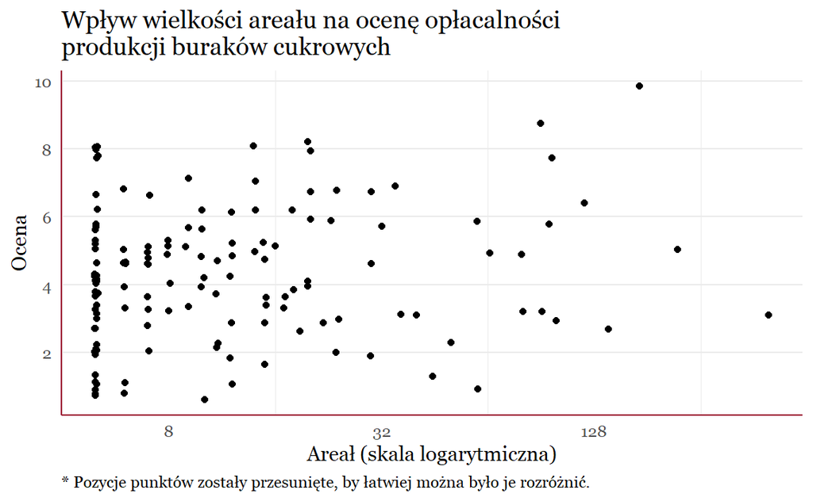

Ocenę wizualną potwierdza również przeprowadzony test korelacji - jest ona nikła ($r = 0,09$) i nieistotna statystycznie ($p = 0,29$). Rzecz wygląda podobnie, jeśli zacząć analizować relację między areałem o oceną opłacalności uprawy w zależności od tego, z którym przedsiębiorstwem respondent ma podpisaną umowę. We wszystkich przypadkach zaobserwowano brak istotnej statystycznie korelacji (dla Krajowej Spółki Cukrowej po tym, gdy usunięto obserwacje odstające).

## Uwagi końcowe

Ocena opłacalności uprawy buraków cukrowych przez respondentów okazała się względnie niska, lecz nie udało się określić czynników różnicujących oceny. Zauważono co prawda różnice wynikające z tego, z którym przedsiębiorstwem cukrowym podpisano umowę na sprzedaż buraków cukrowych (negatywnie wypadło Nordzucker w porównaniu z Krajową Spółką Cukrową oraz Pfeifer & Langen), ale są to wyniki wyłącznie w części satysfakcjonujące - nie odpowiadają one bowiem na pytanie, co dokładnie kryje się za zaobserwowanymi różnicami.

Wyniki, które okazały się statystycznie nieistotne nie przesadząją oczywiście o tym, czy efekt istnieje - można wszak mówić w tym przypadku jedynie o tym, że czegoś nie zaobserwowano, a nie, że tego nie ma. W szczególności, brak efektu w wielu z opisanych przypadków może wynikać z niedostatecznej liczebności próbki w danych podgrupach. Studia, które kontrolowałyby te czynniki, powinny przynieść pewniejsze odpowiedzi na postawione w tym opracowaniu pytania.